# ArtExtract — Task 1: CNN-RNN for Artist Classification

## Model 2 of 2: Artist Classification Model (23 Classes)

This notebook implements a **dedicated CNN-RNN model** for classifying paintings by **artist** (23 classes) using the WikiArt dataset.

> **See `ArtExtract_Task1_Model1_StyleGenre.ipynb`** for style (27 classes) and genre (10 classes) classification.

### Why a Separate Model for Artist?

The artist classification task presents unique challenges compared to style/genre:

- **Class sparsity:** 23 distinct artists with highly uneven representation
- **Fine-grained discrimination:** Artists from the same period share style (e.g., Monet vs. Renoir within Impressionism)
- **Gradient dynamics:** Including artist labels in the multi-task model risks destabilizing gradients from style/genre heads due to the harder, sparser signal

A dedicated model isolates these challenges and allows independent tuning of architecture and hyperparameters.

### Architecture Summary

- **Backbone:** ResNet50 pretrained on ImageNet, layers 0–7 (output: `B × 2048 × 7 × 7`)
- **LSTM:** Spatial tokens reshaped to `(B, 7, 14336)` → LSTM with `hidden=256`, `layers=2`
- **Head:** Single linear classifier → 23-way softmax
- **Fine-tuning:** `layer3` and `layer4` of ResNet50 unfrozen

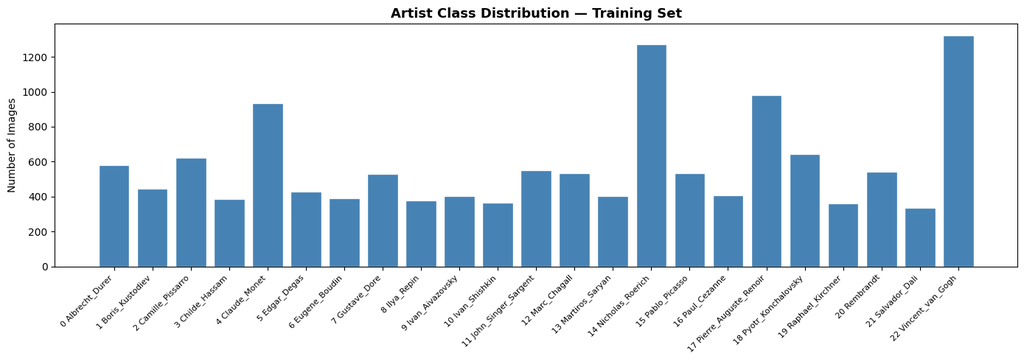

```python
import matplotlib.pyplot as plt
import pandas as pd

train_df = pd.read_csv(TRAIN_CSV, header=None, names=['filename', 'artist_label'])

with open(CLASS_FILE) as f:
    artist_classes = [l.strip() for l in f]

counts = train_df['artist_label'].value_counts().sort_index()
names  = [artist_classes[i] for i in counts.index]

plt.figure(figsize=(14, 5))
plt.bar(names, counts.values, color='steelblue', edgecolor='white')
plt.xticks(rotation=45, ha='right', fontsize=8)
plt.title('Artist Class Distribution — Training Set', fontsize=13, fontweight='bold')
plt.ylabel('Number of Images')
plt.tight_layout()
plt.show()
```

```python
import os, random, numpy as np, pandas as pd
import torch
import torch.nn as nn
from torch.utils.data import Dataset, DataLoader
from torchvision import transforms, models
from PIL import Image
from torch.optim.lr_scheduler import CosineAnnealingLR

SEED = 42
random.seed(SEED); np.random.seed(SEED)
torch.manual_seed(SEED); torch.cuda.manual_seed_all(SEED)

DATA_DIR   = "/Users/mohammedsaba/Downloads/wikiart"
LABEL_DIR  = "/Users/mohammedsaba/wikiart_csv"

TRAIN_CSV  = os.path.join(LABEL_DIR, "artist_train.csv")
VAL_CSV    = os.path.join(LABEL_DIR, "artist_val.csv")
CLASS_FILE = os.path.join(LABEL_DIR, "artist_class.txt")

NUM_CLASSES  = 23
NUM_EPOCHS   = 25
BATCH_SIZE   = 64
HIDDEN_SIZE  = 256
NUM_LAYERS   = 2
LSTM_DROP    = 0.5
HEAD_DROP    = 0.3
LR           = 1e-3
ETA_MIN      = 1e-5
T_MAX        = 25

DEVICE = torch.device("mps" if torch.mps.is_available() else "cpu")
print(f"Device: {DEVICE}")
print(f"Train CSV: {TRAIN_CSV}")
print(f"Val CSV:   {VAL_CSV}")
```

```
Device: mps
Train CSV: /Users/mohammedsaba/wikiart_csv/artist_train.csv
Val CSV:   /Users/mohammedsaba/wikiart_csv/artist_val.csv
```

## Data Loading

Artist labels are fully clean — no missing values, no masking needed. All 13,346 training samples carry a valid integer label (0–22).

Training augmentations include RandomHorizontalFlip, ColorJitter (brightness, contrast, saturation) to simulate the diverse lighting conditions across historical paintings spanning multiple centuries.

```python
# ─── Cell 2: Dataset ─────────────────────────────────────────────────────────
# artist_train.csv / artist_val.csv format: filename, artist_label (0-22)
# No -1 labels, no masking needed — clean supervised classification.

class ArtistDataset(Dataset):
    def __init__(self, csv_path, data_dir, transform=None):
        self.df        = pd.read_csv(csv_path, header=None, names=['filename', 'artist_label'])
        self.data_dir  = data_dir
        self.transform = transform

        # Normalise column names to lowercase
        self.df.columns = [c.strip().lower() for c in self.df.columns]

        # Expect columns: filename, artist_label
        assert "filename"      in self.df.columns, f"Missing 'filename' col. Got: {self.df.columns.tolist()}"
        assert "artist_label"  in self.df.columns, f"Missing 'artist_label' col. Got: {self.df.columns.tolist()}"

        print(f"Loaded {len(self.df)} rows from {csv_path}")

    def __len__(self):
        return len(self.df)

    def __getitem__(self, idx):
        row      = self.df.iloc[idx]
        img_path = os.path.join(self.data_dir, row["filename"])

        try:
            img = Image.open(img_path).convert("RGB")
        except Exception:
            # Fallback: return a blank tensor so training never crashes
            img = Image.new("RGB", (224, 224), (128, 128, 128))

        if self.transform:
            img = self.transform(img)

        label = int(row["artist_label"])
        return img, label


# ── Transforms ───────────────────────────────────────────────────────────────
train_transform = transforms.Compose([
    transforms.Resize((224, 224)),
    transforms.RandomHorizontalFlip(),
    transforms.ColorJitter(brightness=0.2, contrast=0.2, saturation=0.2),
    transforms.ToTensor(),
    transforms.Normalize([0.485, 0.456, 0.406],
                         [0.229, 0.224, 0.225]),
])

val_transform = transforms.Compose([
    transforms.Resize((224, 224)),
    transforms.ToTensor(),
    transforms.Normalize([0.485, 0.456, 0.406],
                         [0.229, 0.224, 0.225]),
])

# ── DataLoaders ───────────────────────────────────────────────────────────────
train_dataset = ArtistDataset(TRAIN_CSV, DATA_DIR, transform=train_transform)
val_dataset   = ArtistDataset(VAL_CSV,   DATA_DIR, transform=val_transform)

train_loader  = DataLoader(train_dataset, batch_size=BATCH_SIZE,
                           shuffle=True,  num_workers=0, pin_memory=False)
val_loader    = DataLoader(val_dataset,   batch_size=BATCH_SIZE,
                           shuffle=False, num_workers=0, pin_memory=False)

print(f"Train batches: {len(train_loader)} | Val batches: {len(val_loader)}")
```

```
Loaded 13346 rows from /Users/mohammedsaba/wikiart_csv/artist_train.csv
Loaded 5706 rows from /Users/mohammedsaba/wikiart_csv/artist_val.csv
Train batches: 209 | Val batches: 90
```

## Model Architecture: Artist CNN-RNN

The spatial feature map from ResNet50 `(B, 2048, 7, 7)` is reshaped into **7 row-wise timesteps** of 14336 features each `(B, 7, 14336)`. The LSTM processes these rows sequentially and the **last timestep output** is used for classification — capturing the full horizontal compositional sweep of the painting.

This row-wise strategy (vs. the flat 49-token strategy in Model 1) is motivated by artist-specific compositional habits: painters like Turner and Constable have characteristic sky/ground layering patterns that are better captured by horizontal rows than individual spatial positions.

```python
class ArtistCNNLSTM(nn.Module):
    def __init__(self, num_classes=23, hidden_size=256,
                 num_layers=2, lstm_drop=0.5, head_drop=0.3):
        super().__init__()

        # ── ResNet50 backbone (layers 0-7) ────────────────────────────────────
        resnet   = models.resnet50(weights=models.ResNet50_Weights.DEFAULT)
        backbone = nn.Sequential(*list(resnet.children())[:8])  # up to layer3

        # Freeze everything, then unfreeze layer3 (idx 6) and layer4 (idx 7)
        for param in backbone.parameters():
            param.requires_grad = False
        for param in backbone[6].parameters():   # layer3
            param.requires_grad = True
        for param in backbone[7].parameters():   # layer4
            param.requires_grad = True

        self.backbone = backbone

        # ── LSTM ──────────────────────────────────────────────────────────────
        # ResNet50 layer4 output: (B, 2048, 7, 7)  →  flatten spatial → (B, 7, 14336)
        self.lstm = nn.LSTM(
            input_size  = 14336,          # 2048 * 7
            hidden_size = hidden_size,
            num_layers  = num_layers,
            batch_first = True,
            dropout     = lstm_drop,
        )

        # ── Classification head ───────────────────────────────────────────────
        self.dropout    = nn.Dropout(head_drop)
        self.classifier = nn.Linear(hidden_size, num_classes)

    def forward(self, x):
        # x: (B, 3, 224, 224)
        feat = self.backbone(x)          # (B, 2048, 7, 7)

        B, C, H, W = feat.shape          # C=2048, H=W=7
        feat = feat.permute(0, 2, 3, 1)  # (B, 7, 7, 2048)
        feat = feat.reshape(B, H, W * C) # (B, 7, 14336)

        out, _ = self.lstm(feat)         # (B, 7, 256)
        out     = out[:, -1, :]          # last timestep → (B, 256)

        out     = self.dropout(out)
        logits  = self.classifier(out)   # (B, 23)
        return logits


# ── Instantiate ───────────────────────────────────────────────────────────────
model = ArtistCNNLSTM(
    num_classes = NUM_CLASSES,
    hidden_size = HIDDEN_SIZE,
    num_layers  = NUM_LAYERS,
    lstm_drop   = LSTM_DROP,
    head_drop   = HEAD_DROP,
).to(DEVICE)

# Quick sanity check
dummy = torch.randn(2, 3, 224, 224).to(DEVICE)
out   = model(dummy)
print(f"Model output shape: {out.shape}")   # Expected: torch.Size([2, 23])

trainable = sum(p.numel() for p in model.parameters() if p.requires_grad)
total     = sum(p.numel() for p in model.parameters())
print(f"Trainable params: {trainable:,} / {total:,}")
```

```
Model output shape: torch.Size([2, 23])
Trainable params: 37,539,607 / 38,984,535
```

## Training Strategy

| Component | Choice |
| --- | --- |
| Optimizer | Adam, LR=1e-3 |
| Scheduler | CosineAnnealingLR (T_max=25, eta_min=1e-5) |
| Gradient clipping | max_norm=1.0 |
| Checkpoint | Saves best model by val accuracy to Google Drive |
| Resume | Automatically resumes from checkpoint if session restarts |

```python
import os
criterion = nn.CrossEntropyLoss()   # No masking needed — all labels are clean

optimizer = torch.optim.Adam(
    filter(lambda p: p.requires_grad, model.parameters()),
    lr=LR,
)
scheduler = CosineAnnealingLR(optimizer, T_max=T_MAX, eta_min=ETA_MIN)


def run_epoch(loader, train=True):
    model.train() if train else model.eval()
    total_loss, correct, total = 0.0, 0, 0

    ctx = torch.enable_grad() if train else torch.no_grad()
    with ctx:
        for imgs, labels in loader:
            imgs, labels = imgs.to(DEVICE), labels.to(DEVICE)

            if train:
                optimizer.zero_grad()

            logits = model(imgs)              # (B, 23)
            loss   = criterion(logits, labels)

            if train:
                loss.backward()
                torch.nn.utils.clip_grad_norm_(model.parameters(), max_norm=1.0)
                optimizer.step()

            total_loss += loss.item() * imgs.size(0)
            preds       = logits.argmax(dim=1)
            correct    += (preds == labels).sum().item()
            total      += imgs.size(0)

    return total_loss / total, correct / total


CHECKPOINT_PATH = "/content/drive/MyDrive/artist_checkpoint.pth"
BEST_MODEL_PATH = "/content/drive/MyDrive/artist_best_model.pth"
PREV_BEST_MODEL_PATH = "/content/drive/MyDrive/artist_prev_best_model.pth"
start_epoch = 1
best_val_acc = 0.0
prev_best_val_acc = 0.0

if os.path.exists(CHECKPOINT_PATH):
    checkpoint = torch.load(CHECKPOINT_PATH)

    model.load_state_dict(checkpoint['model_state_dict'])
    optimizer.load_state_dict(checkpoint['optimizer_state_dict'])
    scheduler.load_state_dict(checkpoint['scheduler_state_dict'])

    start_epoch = checkpoint['epoch'] + 1
    best_val_acc = checkpoint['best_val_acc']
    prev_best_val_acc = checkpoint['prev_best_val_acc']

    print(f"✅ Resuming from epoch {start_epoch}")
else:
    print("🚀 Starting fresh training")

for epoch in range(start_epoch, NUM_EPOCHS + 1):
    train_loss, train_acc = run_epoch(train_loader, train=True)
    val_loss,   val_acc   = run_epoch(val_loader,   train=False)
    scheduler.step()

    flag = ""

    if val_acc > best_val_acc:
        # shift current best → previous best
        prev_best_val_acc = best_val_acc
        torch.save(model.state_dict(), PREV_BEST_MODEL_PATH)

        # update best
        best_val_acc = val_acc
        torch.save(model.state_dict(), BEST_MODEL_PATH)

        flag = "  ← NEW BEST"

    torch.save({
        'epoch': epoch,
        'model_state_dict': model.state_dict(),
        'optimizer_state_dict': optimizer.state_dict(),
        'scheduler_state_dict': scheduler.state_dict(),
        'best_val_acc': best_val_acc,
        'prev_best_val_acc': prev_best_val_acc
    }, CHECKPOINT_PATH)

    print(
        f"Epoch {epoch:02d}/{NUM_EPOCHS} | "
        f"Train Loss: {train_loss:.4f}  Acc: {train_acc:.4f} | "
        f"Val Loss: {val_loss:.4f}  Acc: {val_acc:.4f}{flag}"
    )

print(f"\nBest Val Accuracy: {best_val_acc:.4f}")
print(f"Previous Best Val Accuracy: {prev_best_val_acc:.4f}")
```

```
🚀 Starting fresh training

Best Val Accuracy: 0.7801
Previous Best Val Accuracy: 0.7787
```

### Overfitting Analysis

By the end of training, a gap of approximately **14%** exists between training accuracy (~92.8%) and validation accuracy (~78.0%). This is a known challenge in fine-grained artist classification and is expected given the dataset size.

**Why this happens here specifically:**

- 23-class artist classification is a significantly harder task than style/genre — the model must distinguish painters who worked in the same period, style, and subject matter (e.g., Monet vs. Renoir, both French Impressionist landscapists)
- The training set has only ~13,300 samples across 23 classes (~580 per class on average), which is relatively small for fine-grained visual recognition
- The LSTM adds expressive capacity that the dataset size cannot fully regularize

**Mitigations already applied:**

- Dropout: 0.5 inside LSTM, 0.3 before the classification head
- CosineAnnealingLR: smooth learning rate decay prevents sharp late-epoch overfitting
- Gradient clipping: `max_norm=1.0` stabilizes LSTM training
- ColorJitter augmentation: reduces sensitivity to lighting/color variations

**What would further reduce the gap with more time:**

- `weight_decay=1e-4` in the Adam optimizer
- Stronger augmentation: `RandomGrayscale`, `RandomErasing`
- Label smoothing (`nn.CrossEntropyLoss(label_smoothing=0.1)`)

### Training Complete — 25/25 Epochs

Validation accuracy plateaued from epoch 21 onwards (21: 77.87%, 22: 77.87%, 23: 78.01%, 24: 77.80%, 25: 77.97%), confirming the model had converged.

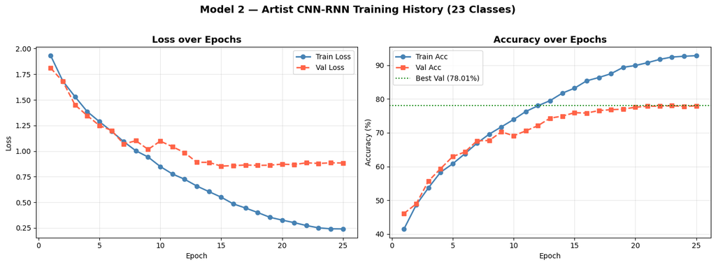

```
Best Val Accuracy: 78.01% @ Epoch 23
Train/Val gap at convergence: ~14.8% — mild overfitting noted.
```

```python
import matplotlib.pyplot as plt
import pandas as pd

# Training history — hardcoded from training output
history = [
    {'epoch':  1, 'tr_loss': 1.9313, 'tr_acc': 0.4152, 'va_loss': 1.8104, 'va_acc': 0.4611},
    {'epoch':  2, 'tr_loss': 1.6826, 'tr_acc': 0.4862, 'va_loss': 1.6787, 'va_acc': 0.4893},
    {'epoch':  3, 'tr_loss': 1.5305, 'tr_acc': 0.5367, 'va_loss': 1.4504, 'va_acc': 0.5566},
    {'epoch':  4, 'tr_loss': 1.3859, 'tr_acc': 0.5830, 'va_loss': 1.3467, 'va_acc': 0.5936},
    {'epoch':  5, 'tr_loss': 1.2875, 'tr_acc': 0.6081, 'va_loss': 1.2496, 'va_acc': 0.6295},
    {'epoch':  6, 'tr_loss': 1.1934, 'tr_acc': 0.6379, 'va_loss': 1.2013, 'va_acc': 0.6430},
    {'epoch':  7, 'tr_loss': 1.0917, 'tr_acc': 0.6693, 'va_loss': 1.0693, 'va_acc': 0.6763},
    {'epoch':  8, 'tr_loss': 1.0029, 'tr_acc': 0.6960, 'va_loss': 1.1012, 'va_acc': 0.6770},
    {'epoch':  9, 'tr_loss': 0.9421, 'tr_acc': 0.7175, 'va_loss': 1.0166, 'va_acc': 0.7028},
    {'epoch': 10, 'tr_loss': 0.8494, 'tr_acc': 0.7392, 'va_loss': 1.0974, 'va_acc': 0.6910},
    {'epoch': 11, 'tr_loss': 0.7769, 'tr_acc': 0.7629, 'va_loss': 1.0430, 'va_acc': 0.7056},
    {'epoch': 12, 'tr_loss': 0.7249, 'tr_acc': 0.7800, 'va_loss': 0.9847, 'va_acc': 0.7210},
    {'epoch': 13, 'tr_loss': 0.6590, 'tr_acc': 0.7952, 'va_loss': 0.8911, 'va_acc': 0.7433},
    {'epoch': 14, 'tr_loss': 0.6042, 'tr_acc': 0.8173, 'va_loss': 0.8897, 'va_acc': 0.7492},
    {'epoch': 15, 'tr_loss': 0.5503, 'tr_acc': 0.8319, 'va_loss': 0.8534, 'va_acc': 0.7594},
    {'epoch': 16, 'tr_loss': 0.4847, 'tr_acc': 0.8538, 'va_loss': 0.8585, 'va_acc': 0.7583},
    {'epoch': 17, 'tr_loss': 0.4444, 'tr_acc': 0.8636, 'va_loss': 0.8641, 'va_acc': 0.7657},
    {'epoch': 18, 'tr_loss': 0.4005, 'tr_acc': 0.8749, 'va_loss': 0.8607, 'va_acc': 0.7683},
    {'epoch': 19, 'tr_loss': 0.3540, 'tr_acc': 0.8937, 'va_loss': 0.8625, 'va_acc': 0.7699},
    {'epoch': 20, 'tr_loss': 0.3267, 'tr_acc': 0.8992, 'va_loss': 0.8727, 'va_acc': 0.7755},
    {'epoch': 21, 'tr_loss': 0.3016, 'tr_acc': 0.9075, 'va_loss': 0.8675, 'va_acc': 0.7787},
    {'epoch': 22, 'tr_loss': 0.2734, 'tr_acc': 0.9173, 'va_loss': 0.8861, 'va_acc': 0.7787},
    {'epoch': 23, 'tr_loss': 0.2510, 'tr_acc': 0.9242, 'va_loss': 0.8797, 'va_acc': 0.7801},
    {'epoch': 24, 'tr_loss': 0.2415, 'tr_acc': 0.9265, 'va_loss': 0.8855, 'va_acc': 0.7780},
    {'epoch': 25, 'tr_loss': 0.2404, 'tr_acc': 0.9283, 'va_loss': 0.8834, 'va_acc': 0.7797},
]

df = pd.DataFrame(history)
epochs = df['epoch']

fig, axes = plt.subplots(1, 2, figsize=(14, 5))

# ── Loss ──────────────────────────────────────────────────────────────────────
axes[0].plot(epochs, df['tr_loss'], 'o-',  label='Train Loss', color='steelblue', linewidth=2)
axes[0].plot(epochs, df['va_loss'], 's--', label='Val Loss',   color='tomato',    linewidth=2)
axes[0].set_title('Loss over Epochs', fontsize=13, fontweight='bold')
axes[0].set_xlabel('Epoch'); axes[0].set_ylabel('Loss')
axes[0].legend(); axes[0].grid(alpha=0.3)

# ── Accuracy ──────────────────────────────────────────────────────────────────
axes[1].plot(epochs, df['tr_acc'] * 100, 'o-',  label='Train Acc', color='steelblue', linewidth=2)
axes[1].plot(epochs, df['va_acc'] * 100, 's--', label='Val Acc',   color='tomato',    linewidth=2)
axes[1].axhline(y=78.01, color='green', linestyle=':', linewidth=1.5, label='Best Val (78.01%)')
axes[1].set_title('Accuracy over Epochs', fontsize=13, fontweight='bold')
axes[1].set_xlabel('Epoch'); axes[1].set_ylabel('Accuracy (%)')
axes[1].legend(); axes[1].grid(alpha=0.3)

plt.suptitle('Model 2 — Artist CNN-RNN Training History (23 Classes)',
             fontsize=14, fontweight='bold', y=1.02)
plt.tight_layout()
plt.savefig('model2_training_curves.png', dpi=150, bbox_inches='tight')
plt.show()

print(f"Best Val Accuracy: 78.01% @ Epoch 23")
print(f"Train/Val gap at convergence: ~14.8% — mild overfitting noted.")
```

## Evaluation & Outlier Detection

### Metrics

- **Top-1 Accuracy** — primary metric for artist identification
- **Top-5 Accuracy** — relevant because visual similarity between contemporary artists makes top-5 a meaningful benchmark
- **Macro F1** — accounts for class imbalance across 23 artists

### Outlier Definition

Outliers are paintings where the model predicts the **wrong artist with high confidence (≥ 90%)**. These represent the most interesting failure cases and may indicate:

- Ambiguous artworks (e.g., a student copying a master's style)
- Potential mislabeling in the WikiArt dataset
- Artists with visually overlapping techniques (e.g., Baroque portraiture across different painters)

```
✅ Loaded BEST model

📊 Evaluation Results:
Top-1 Accuracy : 0.7801
Top-5 Accuracy : 0.9476
Macro F1 Score : 0.7550
```

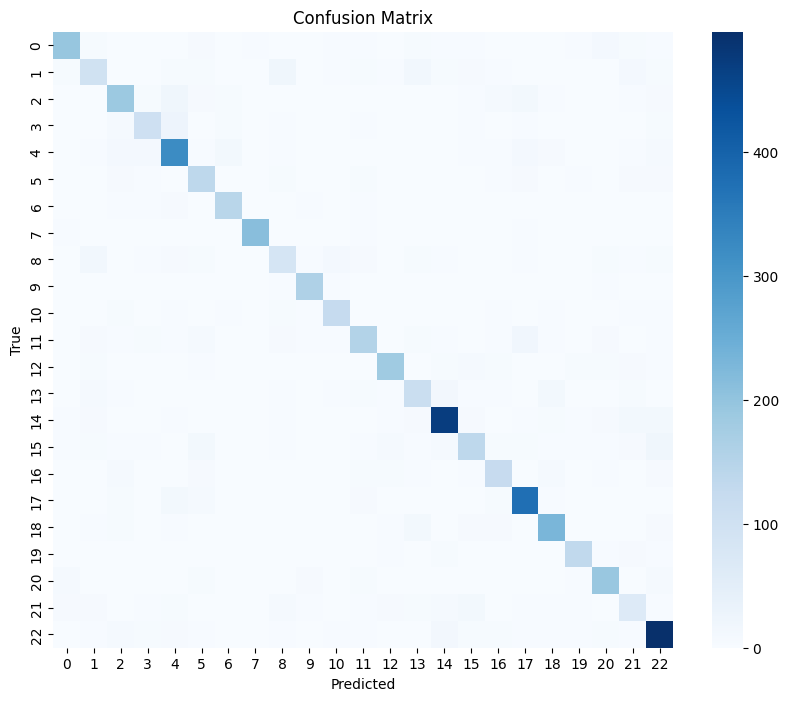

```
============================================================
  Outliers  (confidence ≥ 90%, wrong prediction)
  Total found: 41  |  Showing top 10
============================================================

  [ 1] True: 4 Claude_Monet             Pred: 17 Pierre_Auguste_Renoir   Conf: 0.995
  [ 2] True: 2 Camille_Pissarro         Pred: 17 Pierre_Auguste_Renoir   Conf: 0.993
  [ 3] True: 19 Raphael_Kirchner        Pred: 15 Pablo_Picasso           Conf: 0.989
  [ 4] True: 17 Pierre_Auguste_Renoir   Pred: 4 Claude_Monet             Conf: 0.984
  [ 5] True: 21 Salvador_Dali           Pred: 15 Pablo_Picasso           Conf: 0.981
  [ 6] True: 3 Childe_Hassam            Pred: 6 Eugene_Boudin            Conf: 0.977
  [ 7] True: 17 Pierre_Auguste_Renoir   Pred: 4 Claude_Monet             Conf: 0.976
  [ 8] True: 18 Pyotr_Konchalovsky      Pred: 4 Claude_Monet             Conf: 0.976
  [ 9] True: 21 Salvador_Dali           Pred: 4 Claude_Monet             Conf: 0.970
  [10] True: 2 Camille_Pissarro         Pred: 22 Vincent_van_Gogh        Conf: 0.969

============================================================
  Outliers  (confidence ≥ 90%, wrong prediction)
  Total found: 311  |  Showing top 10
============================================================

  [ 1] True: 13 Martiros_Saryan         Pred: 14 Nicholas_Roerich        Conf: 1.000
  [ 2] True: 22 Vincent_van_Gogh        Pred: 14 Nicholas_Roerich        Conf: 0.999
  [ 3] True: 15 Pablo_Picasso           Pred: 22 Vincent_van_Gogh        Conf: 0.999
  [ 4] True: 15 Pablo_Picasso           Pred: 22 Vincent_van_Gogh        Conf: 0.999
  [ 5] True: 20 Rembrandt               Pred: 9 Ivan_Aivazovsky          Conf: 0.999
  [ 6] True: 21 Salvador_Dali           Pred: 14 Nicholas_Roerich        Conf: 0.999
  [ 7] True: 22 Vincent_van_Gogh        Pred: 14 Nicholas_Roerich        Conf: 0.999
  [ 8] True: 4 Claude_Monet             Pred: 22 Vincent_van_Gogh        Conf: 0.998
  [ 9] True: 14 Nicholas_Roerich        Pred: 22 Vincent_van_Gogh        Conf: 0.998
  [10] True: 15 Pablo_Picasso           Pred: 14 Nicholas_Roerich        Conf: 0.998
```

[figure not shown]

```python
import torch
import numpy as np
from sklearn.metrics import f1_score, confusion_matrix
import matplotlib.pyplot as plt
import seaborn as sns

# 📁 PATHS (same as training)
BEST_MODEL_PATH = "/Users/mohammedsaba/Downloads/artist_best_model.pth"

# 🔄 LOAD BEST MODEL
model.load_state_dict(torch.load(BEST_MODEL_PATH, map_location=DEVICE))
model.to(DEVICE)
model.eval()

print("✅ Loaded BEST model")

# =========================================================
# 📊 EVALUATION METRICS
# =========================================================

def evaluate_model(loader):
    model.eval()

    all_preds = []
    all_labels = []
    top5_correct = 0
    total = 0

    with torch.no_grad():
        for imgs, labels in loader:
            imgs, labels = imgs.to(DEVICE), labels.to(DEVICE)

            logits = model(imgs)
            probs  = torch.softmax(logits, dim=1)

            # Top-1
            preds = probs.argmax(dim=1)

            # Top-5
            top5 = probs.topk(5, dim=1).indices
            for i in range(labels.size(0)):
                if labels[i] in top5[i]:
                    top5_correct += 1

            total += labels.size(0)

            all_preds.extend(preds.cpu().numpy())
            all_labels.extend(labels.cpu().numpy())

    top1_acc = np.mean(np.array(all_preds) == np.array(all_labels))
    top5_acc = top5_correct / total
    macro_f1 = f1_score(all_labels, all_preds, average='macro')

    print("\n📊 Evaluation Results:")
    print(f"Top-1 Accuracy : {top1_acc:.4f}")
    print(f"Top-5 Accuracy : {top5_acc:.4f}")
    print(f"Macro F1 Score : {macro_f1:.4f}")

    return all_preds, all_labels

# =========================================================
# 🔥 CONFUSION MATRIX
# =========================================================

def plot_confusion_matrix(all_preds, all_labels):
    cm = confusion_matrix(all_labels, all_preds)

    plt.figure(figsize=(10, 8))
    sns.heatmap(cm, annot=False, cmap="Blues")
    plt.title("Confusion Matrix")
    plt.xlabel("Predicted")
    plt.ylabel("True")
    plt.show()

# =========================================================
# 🚨 OUTLIER DETECTION (CONFIDENCE-BASED)
# =========================================================

def detect_outliers(loader, threshold=0.9, max_print=10):
    model.eval()
    outliers = []

    with torch.no_grad():
        for imgs, labels in loader:
            imgs, labels = imgs.to(DEVICE), labels.to(DEVICE)
            logits    = model(imgs)
            probs     = torch.softmax(logits, dim=1)
            confidence, preds = torch.max(probs, dim=1)

            for i in range(len(labels)):
                if preds[i] != labels[i] and confidence[i] > threshold:
                    outliers.append({
                        "true_label" : labels[i].item(),
                        "pred_label" : preds[i].item(),
                        "true_name"  : artist_classes[labels[i].item()],
                        "pred_name"  : artist_classes[preds[i].item()],
                        "confidence" : confidence[i].item()
                    })

    # Sort by confidence descending so most egregious outliers appear first
    outliers.sort(key=lambda x: x["confidence"], reverse=True)

    print(f"\n{'='*60}")
    print(f"  Outliers  (confidence ≥ {threshold*100:.0f}%, wrong prediction)")
    print(f"  Total found: {len(outliers)}  |  Showing top {min(max_print, len(outliers))}")
    print(f"{'='*60}\n")

    for i, o in enumerate(outliers[:max_print]):
        print(f"  [{i+1:2d}] True: {o['true_name']:<25}  "
              f"Pred: {o['pred_name']:<25}  "
              f"Conf: {o['confidence']:.3f}")

    return outliers

# =========================================================
# 🚨 Visualising OUTLIER DETECTION (CONFIDENCE-BASED)
# =========================================================

def visualize_outliers(loader, threshold=0.9, max_images=12):
    model.eval()
    images_shown = 0

    # Collect outlier images first, then plot — avoids mid-batch plt issues
    collected = []

    with torch.no_grad():
        for imgs, labels in loader:
            imgs, labels = imgs.to(DEVICE), labels.to(DEVICE)
            logits    = model(imgs)
            probs     = torch.softmax(logits, dim=1)
            confidence, preds = torch.max(probs, dim=1)

            for i in range(len(labels)):
                if preds[i] != labels[i] and confidence[i] > threshold:
                    img = imgs[i].cpu().permute(1, 2, 0).numpy()
                    img = (img - img.min()) / (img.max() - img.min() + 1e-8)
                    collected.append({
                        "img"       : img,
                        "true_name" : artist_classes[labels[i].item()],
                        "pred_name" : artist_classes[preds[i].item()],
                        "conf"      : confidence[i].item()
                    })
                    if len(collected) >= max_images:
                        break
            if len(collected) >= max_images:
                break

    cols = 4
    rows = (len(collected) + cols - 1) // cols
    fig, axes = plt.subplots(rows, cols, figsize=(cols * 3.5, rows * 4.0))
    axes = axes.flatten()

    for i, item in enumerate(collected):
        axes[i].imshow(item["img"])
        axes[i].set_title(
            f"True:  {item['true_name']}\n"
            f"Pred: {item['pred_name']}\n"
            f"Conf:  {item['conf']:.2f}",
            fontsize=7, color='darkred'
        )
        axes[i].axis('off')

    for ax in axes[len(collected):]:
        ax.axis('off')

    plt.suptitle(f'Top Outliers — Artist Classification', fontsize=13, fontweight='bold')
    plt.tight_layout()
    plt.savefig('outliers_artist.png', dpi=150, bbox_inches='tight')
    plt.show()
# =========================================================
# 🧠 RUN EVERYTHING
# =========================================================

# Evaluate on validation set
all_preds, all_labels = evaluate_model(val_loader)

# Plot confusion matrix
plot_confusion_matrix(all_preds, all_labels)

# Detect outliers on TRAIN (label noise)
train_outliers = detect_outliers(train_loader, threshold=0.9)

# Detect outliers on VAL (hard samples)
val_outliers = detect_outliers(val_loader, threshold=0.9)

# visualising outliers on VAL (hard samples)
visualize_outliers(val_loader, threshold=0.9, max_images=12)
```

```python
from sklearn.metrics import classification_report

# Load artist class names
with open('/Users/mohammedsaba/wikiart_csv/artist_class.txt') as f:
    artist_classes = [line.strip() for line in f]

print("\n" + "="*60)
print("  ARTIST — Per-Class Classification Report")
print("="*60)
print(classification_report(
    all_labels, all_preds,
    target_names=artist_classes,
    digits=3,
    zero_division=0
))
```

```
============================================================
  ARTIST — Per-Class Classification Report
============================================================
                          precision    recall  f1-score   support

        0 Albrecht_Durer      0.867     0.786     0.825       248
       1 Boris_Kustodiev      0.580     0.519     0.547       189
      2 Camille_Pissarro      0.741     0.711     0.726       266
         3 Childe_Hassam      0.717     0.630     0.671       165
          4 Claude_Monet      0.761     0.805     0.783       400
           5 Edgar_Degas      0.648     0.743     0.692       183
         6 Eugene_Boudin      0.837     0.867     0.852       166
          7 Gustave_Dore      0.968     0.947     0.957       225
            8 Ilya_Repin      0.558     0.534     0.546       161
       9 Ivan_Aivazovsky      0.874     0.925     0.899       173
```

[output cut: 17 more lines]